# Gapminder Exploration

Alex Schmidt

March 16, 2016

I was tasked with investigating the gapminder data set. This data set contains the population, GDP per capita, and life expectancy for 142 countries for 12 years (1952, 1957, 1962, 1967, 1972, 1977, 1982, 1987, 1992, 1997, 2002, 2007).

With this dataset, it is possible to visualize changes over time. Initial questions that one might ask relate to changes over time. For example, we could visualize the progression of life expectancies or GDP per capita over time:

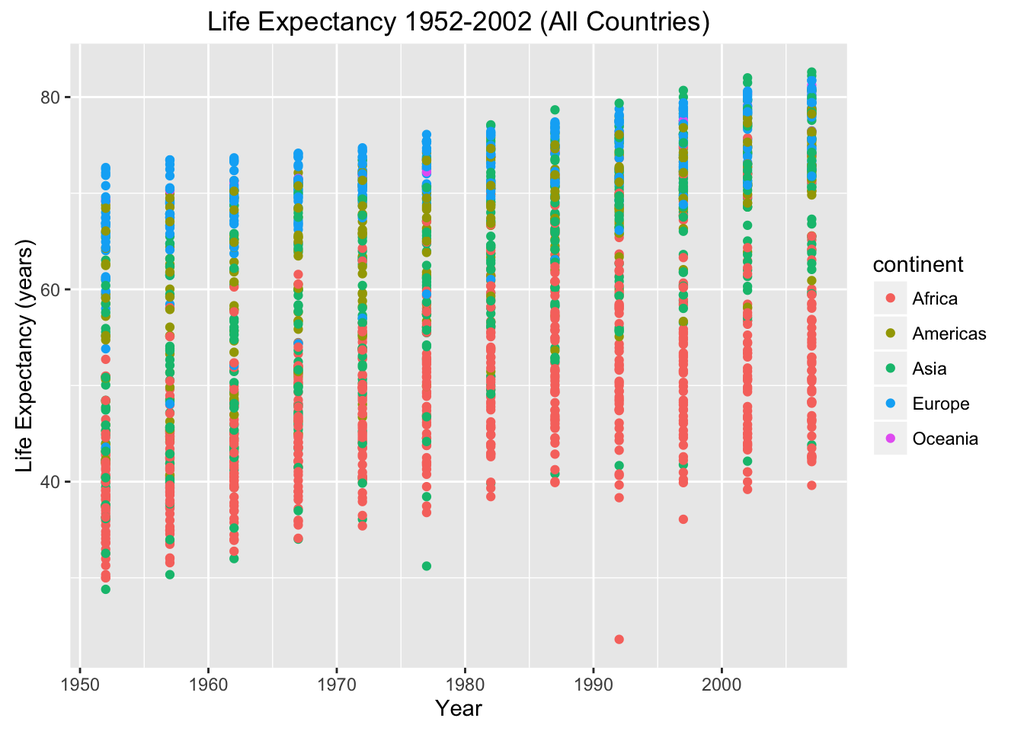

[figure not shown]

The next, perhaps obvious, relationship to investigate is that between life expectancy and GDP per capita.

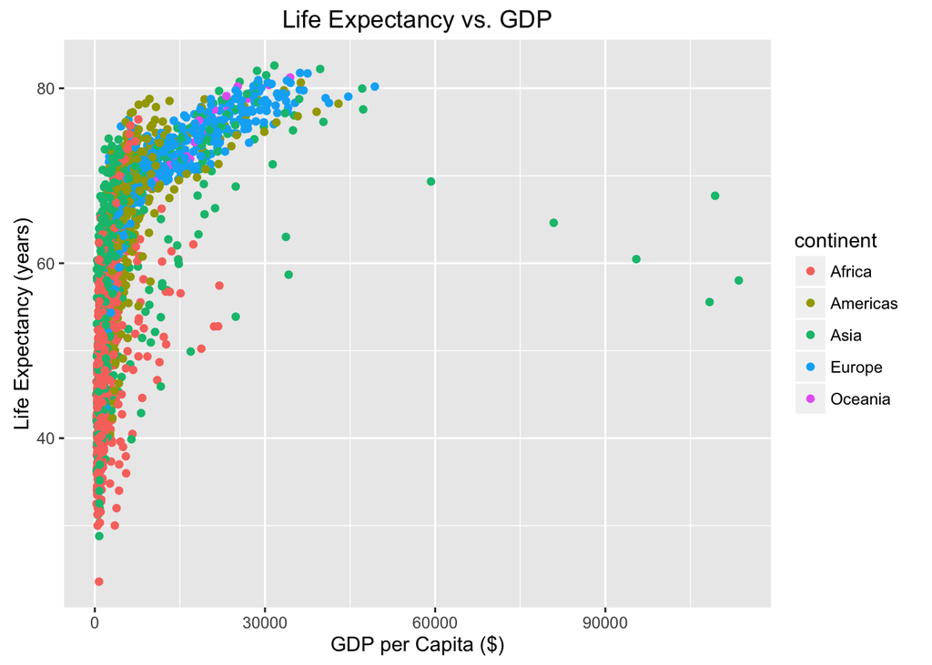

Generally, there seems to be a correlation between GDP per capita and life expectancy. However, that does not seem to hold for all the countries in Asia. Plotting just the Asian countries, we see the following:

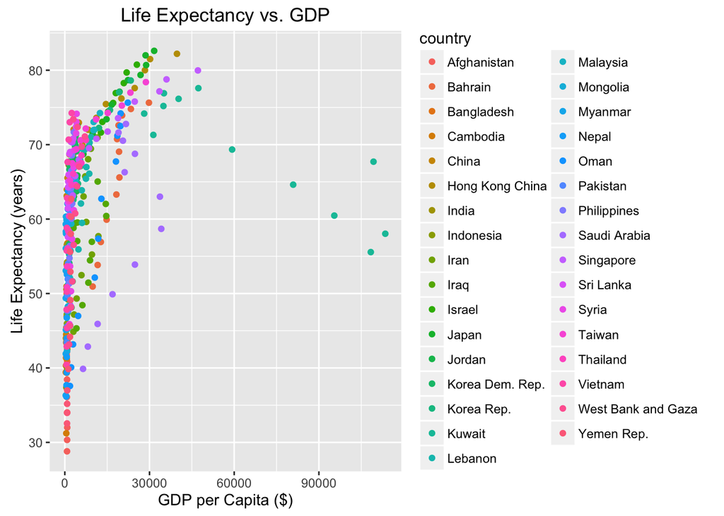

It appears that there is something going on with Kuwait. Let’s further investigate this country. First, how did the life expectancy change over time?

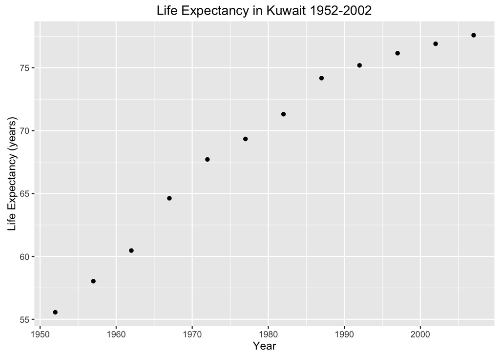

Interesting. What about the GDP per capita?

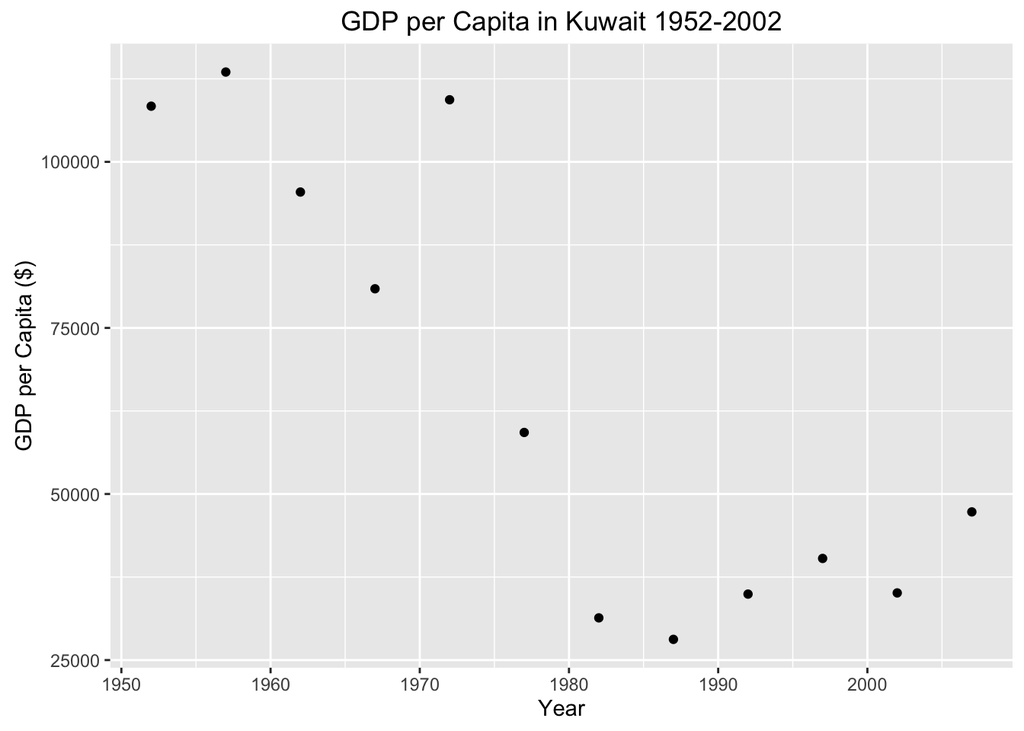

Perhaps Kuwait’s population has something to do with this. If the population exploded but the overall GDP stayed about the same, that could explain this trend.

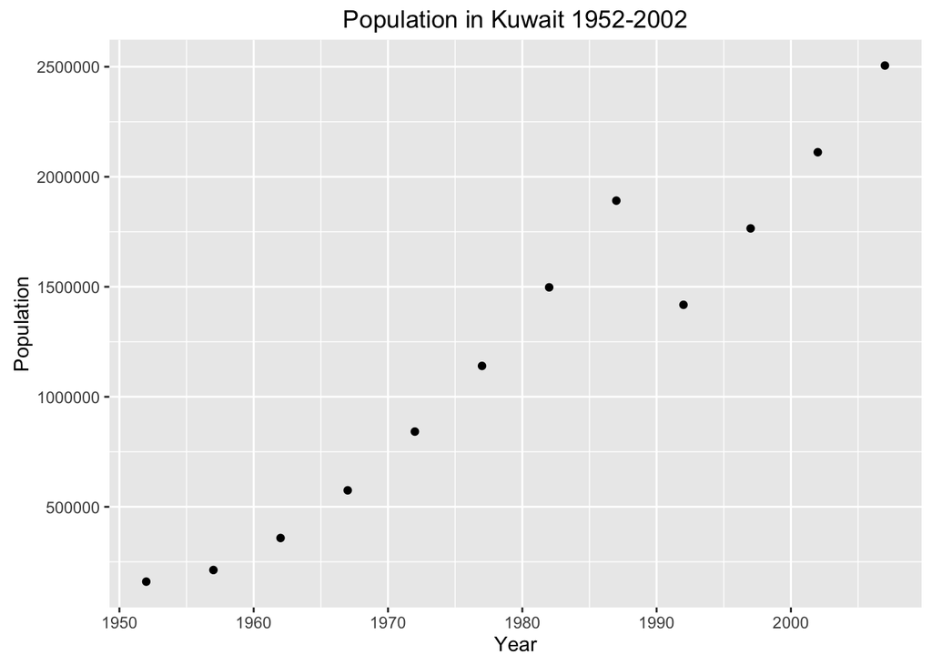

Indeed, Kuwait’s population has seem massive growth. The last thing we need to check is the overall GDP for Kuwait during these years.

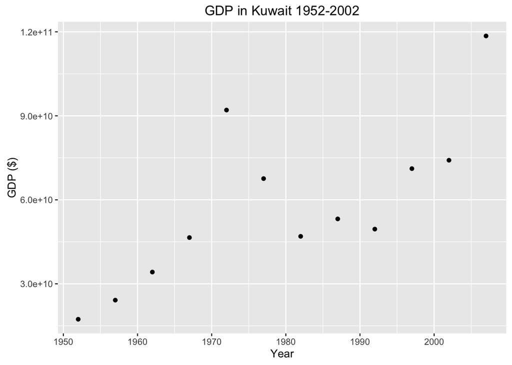

As suspected, Kuwait’s population grew faster than the GDP, accounting for the dip in GDP per capita.